# RP11

聖心女子大学国際交流学科  
2024年秋学期

アジア経済研究所 伊藤成朗

$$2^{0}=1?$$

べき乗のパタン

$$\begin{aligned}
2^{3}
&=
& 2\cdot 2\cdot 2\cdot 1&=8\\
2^{2}
&=
& 2\cdot 2\cdot 1&=4\\
2^{1}
&=
& 2\cdot 1&=2\\
2^{0}
&=
& 1&=1
\end{aligned}$$

べき乗のパタン2

$$\begin{aligned}
2^{2}
&=
\frac{2^{3}}{2}=\frac{8}{2}=4\\
2^{1}
&=
\frac{2^{2}}{2}=\frac{4}{2}=2\\
2^{0}
&=
\frac{2^{1}}{2}=\frac{2}{2}=1
\end{aligned}$$

べき乗の加法

$$2=2^{1}=2^{1+0}=2^{1}\cdot 2^{0}=2\cdot 2^{0} \quad \Longrightarrow \quad 2^{0}=1.$$

上の2つは証明ではありません

べき乗の加法法則を使ったものは証明ぽいです

生成AIの登場により、思考低下が懸念される。また、学校へ行かない（ホームスクール制度、通信）など、学習方法の多様性が見られる。こうした時代の変化の中で、今後労働生産性、資本生産性は向上していくのか。

上記文章には2つの問いがあると思います

1. 人的資本はどう蓄積するか
2. 人的資本が他の生産要素と組み合わさることで労働生産性はどう変わるか

人的資本投資の方法

- 就学(通信学科やホーム・スクーリングを含む)
- 日常生活での経験
- 就労←作業の熟達learning-by-doing

日常生活における人的資本蓄積↓?

- 論理的思考、知識、調べ方・学び方などをAIに一任し、人的資本=AIに尋ねる能力、となる人たちが出現?

生成AIの登場により、思考低下が懸念される。また、学校へ行かない（ホームスクール制度、通信）など、学習方法の多様性が見られる。こうした時代の変化の中で、今後労働生産性、資本生産性は向上していくのか。

Baland and Robinsonモデルの単純化の仮定: 人的資本投資=通学=均一効果

就労でも人的資本は増えます

- Cordon Blu, Londonのパティシエ
- Baland and Robinsonモデルは就学に焦点を当てるために、learning-by-doingは起こらないと想定
  - 起こると想定しても、就学の機会費用が減るだけで、結論は質的に変わりません

同じ学校教育でも、教授法pedagogyが違えば人的資本蓄積度合いも変わるはずです

- 教育学には教授法の効果推計がたくさんあります

生成AIの登場により、思考低下が懸念される。また、学校へ行かない（ホームスクール制度、通信）など、学習方法の多様性が見られる。こうした時代の変化の中で、今後労働生産性、資本生産性は向上していくのか。

人的資本は他の生産要素とどのように組み合わさり、組み合わせによって労働生産性はどのように変わるか

生産関数: 資本$K$と労働$L$を使って財・サービス$y$を産出する技術的関係

$\mathbb R_{+}\times\mathbb R_{+}\to\mathbb R_{+}$ (正の実数×正の実数の組み合わせ$\to$正の実数というマッピング)
$$y=f(K,L).$$

生成AIの登場により、思考低下が懸念される。また、学校へ行かない（ホームスクール制度、通信）など、学習方法の多様性が見られる。こうした時代の変化の中で、今後労働生産性、資本生産性は向上していくのか。

2変数関数$f(K, L)$を1つの変数で微分=偏微分partial differentiation

$$\frac{\partial f(K,L)}{\partial K}>0, \ \frac{\partial f(K,L)}{\partial L}>0$$

- $\frac{\partial f(K,L)}{\partial K}>0$: **資本の限界生産力**は正=資本投入が増えれば生産も増える (すべての正の$K, L$において)
- $\frac{\partial f(K,L)}{\partial L}>0$: **労働の限界生産力**は正=労働投入が増えれば生産も増える ($\forall K, L\in\mathbb R_{+}^{2}$)

限界生産力=偏微分

生成AIの登場により、思考低下が懸念される。また、学校へ行かない（ホームスクール制度、通信）など、学習方法の多様性が見られる。こうした時代の変化の中で、今後労働生産性、資本生産性は向上していくのか。

$$\frac{\partial\left(\frac{\partial f(K,L)}{\partial L}\right)}{\partial K}=\frac{\partial^{2} f(K,L)}{\partial K\partial L}=\frac{\partial^{2} f(K,L)}{\partial L\partial K}\lesseqgtr 0.$$

- $\frac{\partial^{2} f(K,L)}{\partial K\partial L}$: 資本と労働の**交差限界生産力**cross marginal product=労働の限界生産力は資本が増えると$\lesseqgtr 0$減る・増える・変化無し?

$$\frac{\partial^{2} f(K,L)}{\partial K\partial L}
\left\{
\begin{array}{c}
<\\
=\\
>
\end{array}
\right.
0 \quad \Leftarrow \quad
y=
\left\{
\begin{array}{l}
\mbox{該当無し}\\
K+L\\
KL
\end{array}
\right.$$

生成AIの登場により、思考低下が懸念される。また、学校へ行かない（ホームスクール制度、通信）など、学習方法の多様性が見られる。こうした時代の変化の中で、今後労働生産性、資本生産性は向上していくのか。

$$\frac{\partial^{2} f(K,L)}{\partial K\partial L}>0$$

限界労働生産力(労働を僅かに増やすことの生産増)は資本が増えると大きくなる

- 農業: 手作業の人を増やす vs. トラクターを使う人を増やす

$$\frac{\partial^{2} f(K,L)}{\partial K\partial L}=0$$

限界労働生産力(労働を僅かに増やすことの生産増)は資本の大きさと関係ない

- 工場: 製品を機械だけで生産し、人だけで製品を箱詰めする工程

生成AIの登場により、思考低下が懸念される。また、学校へ行かない（ホームスクール制度、通信）など、学習方法の多様性が見られる。こうした時代の変化の中で、今後労働生産性、資本生産性は向上していくのか。

AIを資本と見立てると労働限界生産力をどう変えるでしょうか

- $\partial^{2}f/\partial K\partial L>0$の職種・作業→労働の限界生産力↑ ⇒ 労働需要↑
  - そういう場合もあるでしょう
  - そうではない場合も多そうです
    - 結論が曖昧なのは$f(K, L)$が抽象的すぎるからかも
    - もう少し中身を具体的に詰める必要があります
- 無関係$\partial^{2}f/\partial K\partial L=0$の職種・作業もあります
  - 交差微分がゼロ(限界生産力は互いの量に無関係)の中身をもう少し詳しくしたのが作業ベースの生産関数task-based production function(Autor 2013)です

生成AIの登場により、思考低下が懸念される。また、学校へ行かない（ホームスクール制度、通信）など、学習方法の多様性が見られる。こうした時代の変化の中で、今後労働生産性、資本生産性は向上していくのか。

作業task $i$ベースの生産関数:
$$y(i)=A_{l}\alpha_{l}(i)L_{l}(i)+A_{m}\alpha_{m}(i)L_{m}(i)+A_{h}\alpha_{h}(i)L_{h}(i)+A_{K}\alpha_{K}(i)K(i)$$

- どの生産要素も交差微分がゼロ
- 一定の仮定の下では、作業は資本(ロボット、AI)、低技能労働$L_{l}$、中技能労働$L_{m}$、高技能労働$L_{h}$のどれかが担うようになる
- AIが廉価になって$K$の費用が十分に低くなれば、$K$が多用され、**同じ作業に関わる労働**の需要を減らします
- $K$が多用されても、今までに無かった職種・作業が開発され、**労働の総需要**は減らない可能性もあります
- 代替される労働は比較優位のない異なる作業に就くため、限界生産力は下がります
- AIが発達=導入される作業での資本生産性が高まる

おまけ: 労働の限界(価値)生産力=賃金marginal (value) product of labour=wage

生産物価格$p$、賃金$w$と資本レンタル料$r$、生産技術$f(K, L)$を所与(=「完全競争市場」perfectly competitive markets)、$K, L$を最適に選んで利潤最大化する企業

$$\max_{\{K, L\}}\;\;\;
\pi=pf(K, L)-rK-wL$$

FOCs(微分してゼロと等しいとする)

$$\begin{aligned}
\frac{\partial\pi}{\partial K}=p\frac{\partial f(K, L)}{\partial K}-r&=0, &\quad
\frac{\partial\pi}{\partial L}=p\frac{\partial f(K, L)}{\partial L}-w&=0,\\
\underbrace{p\frac{\partial f(K, L)}{\partial K}}_{\scriptsize{\mbox{資本の限界価値生産力}}}&=\underbrace{r}_{\scriptsize{\mbox{資本レンタル料}}}, &\quad
\underbrace{p\frac{\partial f(K, L)}{\partial L}}_{\scriptsize{\mbox{労働の限界価値生産力}}}&=\underbrace{w}_{\scriptsize{\mbox{賃金}}}
\end{aligned}$$

おまけ2: 労働の買い手独占企業は労働の限界(価値)生産力>賃金marginal (value) product of labour>wage, if monopsonist

買い手独占: 雇用量が賃金に影響する=雇用↑ ⇒ 賃金↑ → $w=w(L), w'(L)>0$

価格$p$、労働供給関数$w(L)$、生産技術$f(L)$を所与(=「労働の不完全競争市場」imperfectly competitive labour market)、$L$で利潤最大化する企業

$$\max_{\{L\}}\;\;\;
\pi=pf(L)-w(L)L$$

FOCs
$$\pi_{L}
=
pf'(L)-w-\frac{\partial w(L)}{\partial L}L=0.$$

$$pf'(L)=w+\frac{\partial w(L)}{\partial L}L, \quad
1=\frac{w}{pf'(L)}+\frac{\partial w(L)}{\partial L}\frac{L}{w}\frac{w}{pf'(L)}=\frac{w}{pf'(L)}\left(1+a\right),
\quad
a := \frac{dw}{dL}\frac{L}{w}>0.$$

$$\color{red}{\mbox{wage markdown}}=\frac{w}{pf'(L)}=\frac{1}{1+a}=\frac{1}{1+\theta^{-1}}<1, \quad
\theta:=a^{-1}=\frac{\frac{dL}{L}}{\frac{dw}{w}} \quad (\mbox{労働供給の賃金弾力性})$$

おまけ3: 独占企業の価格>完全競争の価格monopolist price>competitive price

独占企業: 供給が価格に影響する=生産量↑ ⇒ 価格↓ → $p=p(q), p'(q)<0$.

需要曲線$p(q)$、賃金$w$、生産技術$f(L)$を所与(=「生産物の不完全競争市場」imperfectly competitive product markets)、$L$で利潤最大化する企業

$$\max_{\{L\}}\;\;\;
\pi=p[f(L)]f(L)-wL$$

FOCs
$$\pi_{L}
=
\frac{\partial p(q)}{\partial q}f'(L)f(L)+p(q)f'(L)-w=0.$$

$$p(q)f'(L)\left\{1+\frac{\partial p(q)}{\partial q}\frac{q}{p(q)}\right\}=w,
\quad
p(q)=\frac{w}{f'(L)\left(1-b\right)}>\frac{w}{f'(L)}=p_{\scriptsize{\mbox{pc}}},
\quad b := -\frac{dp}{dq}\frac{q}{p}>0.$$
$$\color{red}{\mbox{markup}}=\frac{p(q)}{p_{\scriptsize{\mbox{pc}}}}=\frac{1}{1-b}=\frac{1}{1-\eta^{-1}}>1, \quad
\eta:=b^{-1}=-\frac{\frac{dq}{q}}{\frac{dp}{p}} \quad (\mbox{需要の価格弾力性})$$

おまけ4: 技術的限界代替率=相対要素価格technical marginal rate of substitution=relative factor price

生産物価格$p$、賃金$w$と資本レンタル料$r$、特定の生産量$q$, 生産技術$f(K, L)$を所与(=「完全競争市場」)、$K, L$を最適に選んで費用最小化する企業

$$\begin{aligned}
\min_{\{K, L\}}\;\;\;&
c=rK+wL\\
\st \;\;\;& q\geqslant f(K,L)
\end{aligned}$$
ラグランジアン: 制約付き最大化・最小化問題で使う関数
$$\mathcal L=rK+wL+\lambda[q-f(K,L)]$$

人的資本は増加している一方、労働分配率は低下していた理由として、モノの価格が高過ぎて、家計に還元されていなかったという内容を聞いて、インフレ時に物価が上昇しているが賃金の上昇が追いついていない状況に似ていると感じました。先進国での1970年代以降の傾向として、労働者所得の成長率が低かったという内容があり、その背景には、企業所有者と株主が所得を増やし、労働者まで十分に還元されなかった点があるという内容が印象的でした。

- デフレが長かったので、大学生がインフレを肌身感覚として持っていることに新鮮な驚きを感じます

若干の誤解があります

講義: 労働分配率低下 ⭕原因の候補、❌確定原因

税金=0と仮定すると、企業の手残り資金=収入-各種生産要素への支払

$$労働分配率=\frac{労働への支払}{収入-各種生産要素への支払}=\frac{賃金+その他}{価格×販売量-各種生産要素への支払}$$

低下要因:

- 賃金増加幅の低下←労働市場の独寡占
- 価格増加幅の上昇←生産物市場の独寡占

人的資本は増加している一方、労働分配率は低下していた理由として、モノの価格が高過ぎて、家計に還元されていなかったという内容を聞いて、インフレ時に物価が上昇しているが賃金の上昇が追いついていない状況に似ていると感じました。先進国での1970年代以降の傾向として、労働者所得の成長率が低かったという内容があり、その背景には、企業所有者と株主が所得を増やし、労働者まで十分に還元されなかった点があるという内容が印象的でした。

現代の日本でも、人的資本↑ ⇒ 労働生産性↑ ⇒ 賃金↑は起こっているはずです

しかし、労働生産性が伸びた分だけ賃金が上昇しているか、さらに言えば、ミクロ経済学で示される以下の関係が成り立っているか分かりません
$$\mbox{労働の限界生産力}=\mbox{賃金}$$

- 労働市場の買い手寡占labour market oligoposony ⇒ 労働の限界生産力>賃金
  - 企業が労働から上がる成果の一部を取る←雇用者間の競争が限られているため
  - wage markdown: 賃金/労働の限界生産力

アメリカ: 資本主義の活力=競争、が失われているという指摘

人的資本は増加している一方、労働分配率は低下していた理由として、モノの価格が高過ぎて、家計に還元されていなかったという内容を聞いて、インフレ時に物価が上昇しているが賃金の上昇が追いついていない状況に似ていると感じました。先進国での1970年代以降の傾向として、労働者所得の成長率が低かったという内容があり、その背景には、企業所有者と株主が所得を増やし、労働者まで十分に還元されなかった点があるという内容が印象的でした。

企業活力business dynamismに関する定型化された10の事実(Akcigit and Ates 2021)

1. Market concentration↑

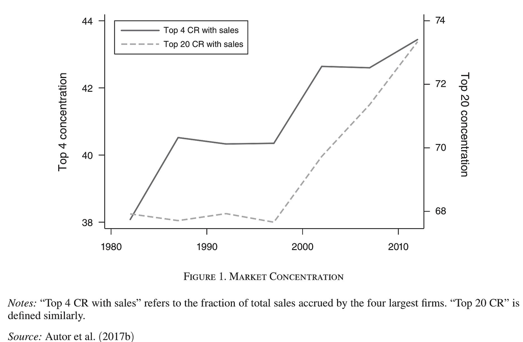

6. (Labour) Productivity gap between frontier and laggard firms↑

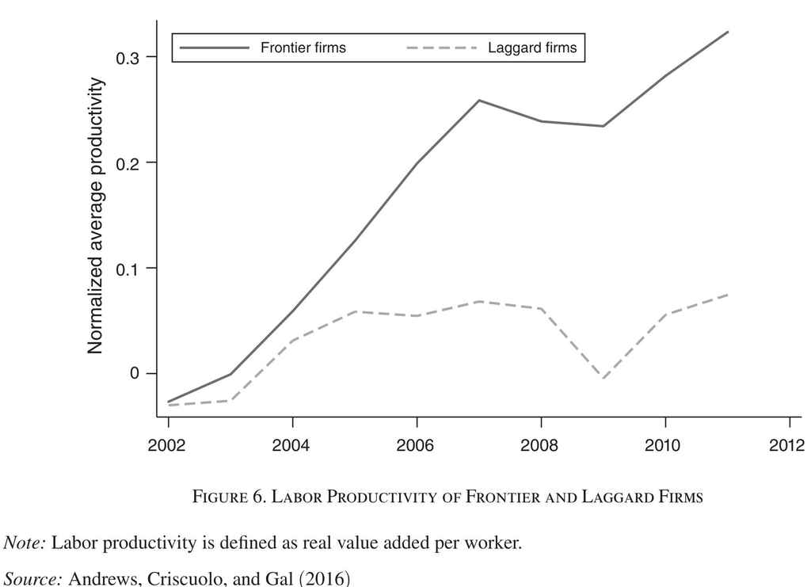

2. Average markups↑

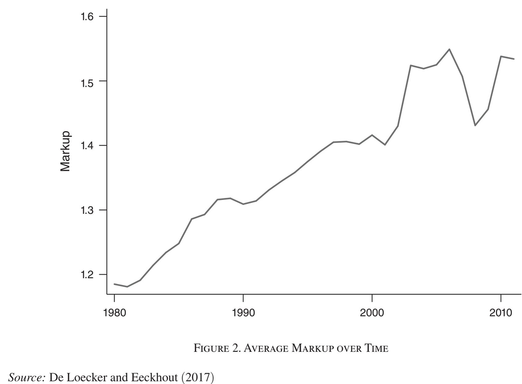

7. Firm entry rate↓

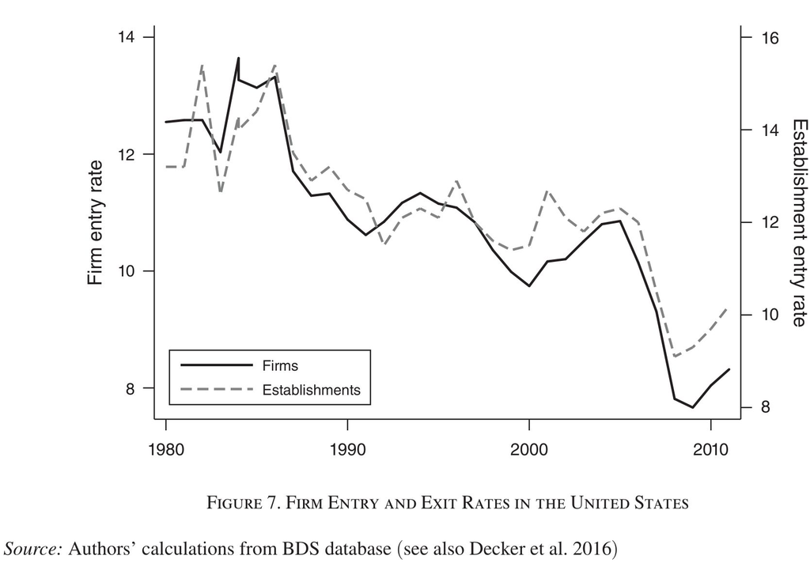

3. Profit share of GDP↑

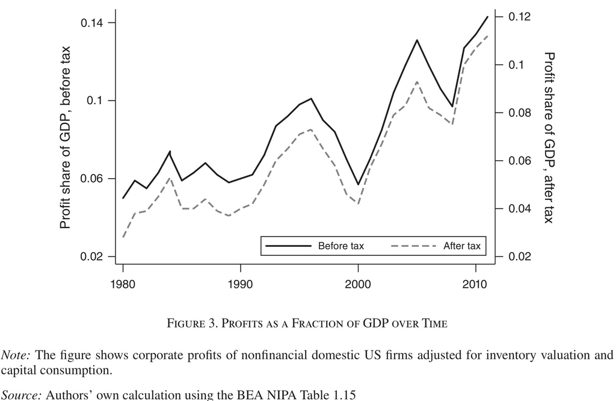

8. Share of young firms↓

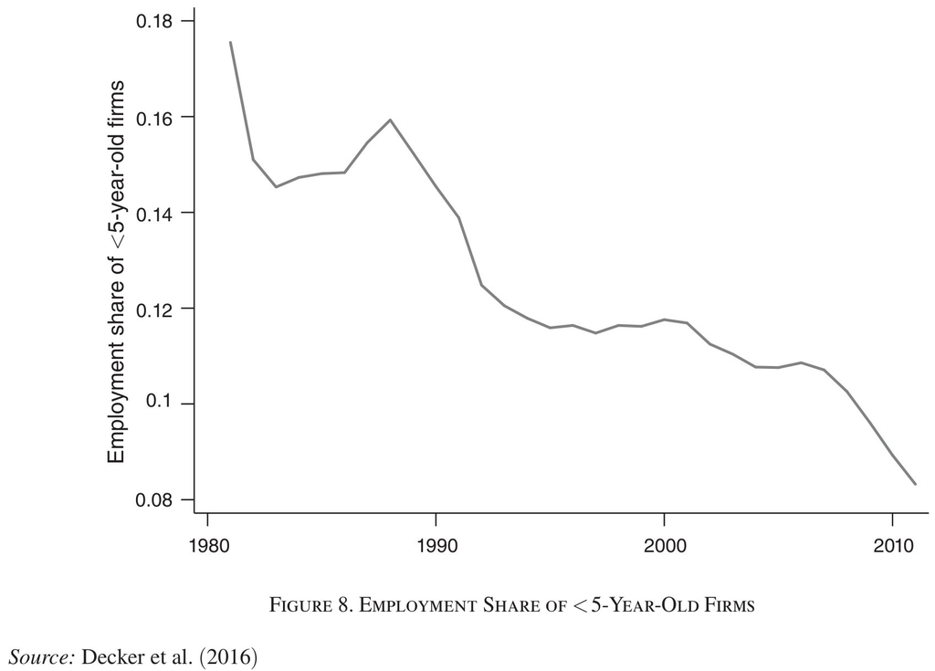

4. Labor share of output↓

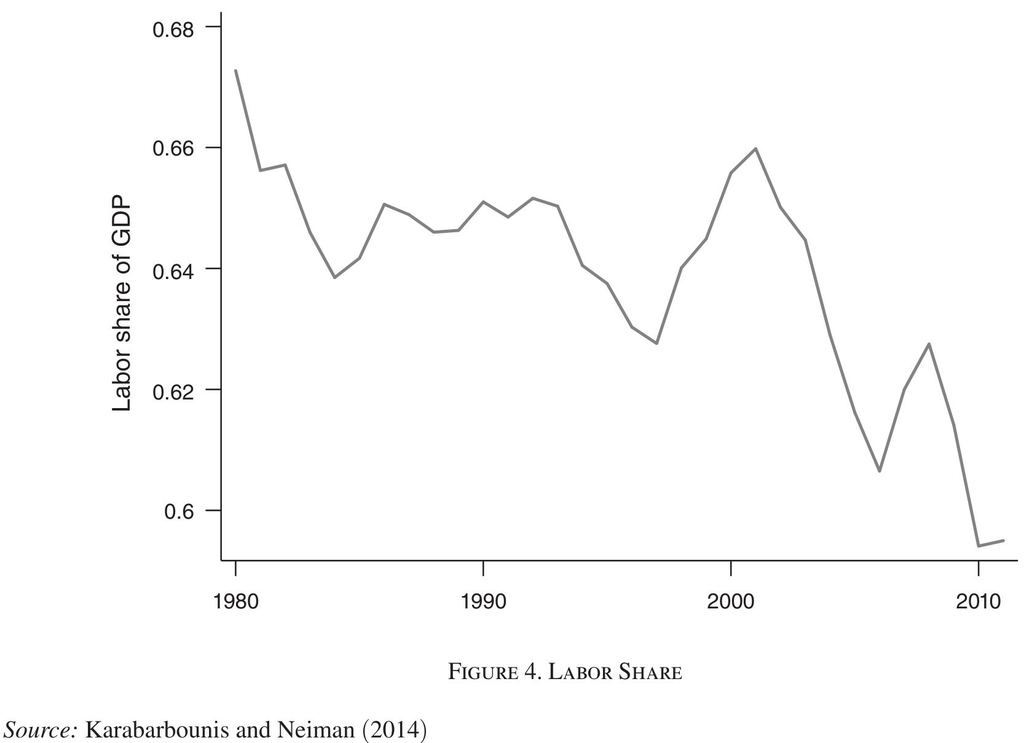

9. Job reallocation↓

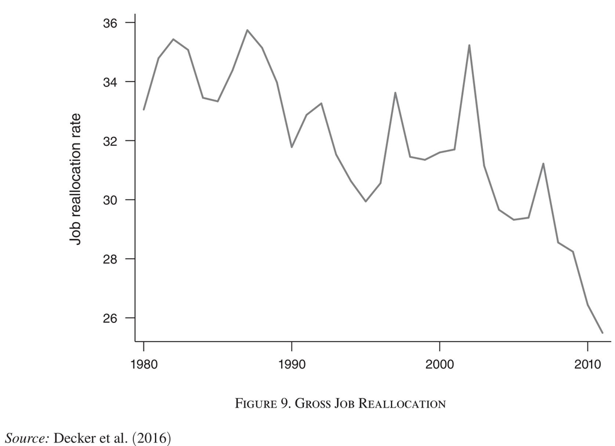

5. Market concentration↑ $\stackrel{+}{\sim}$ L share↓

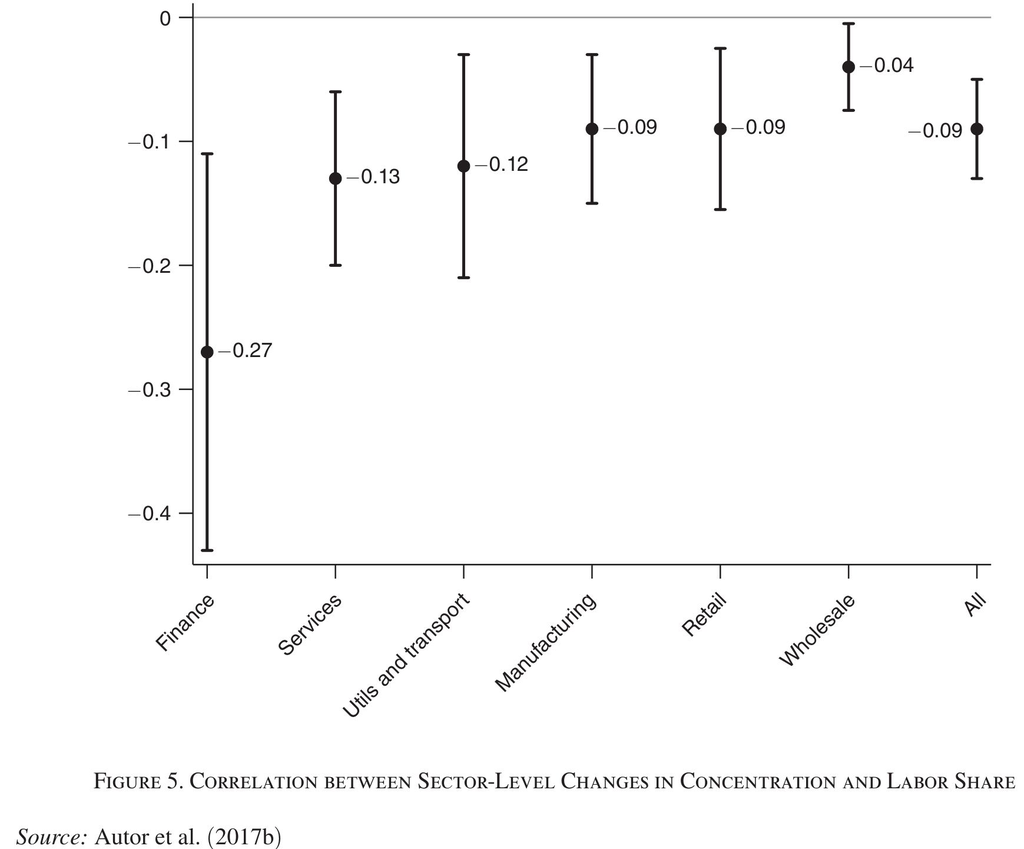

10. dispersion of firm growth↓

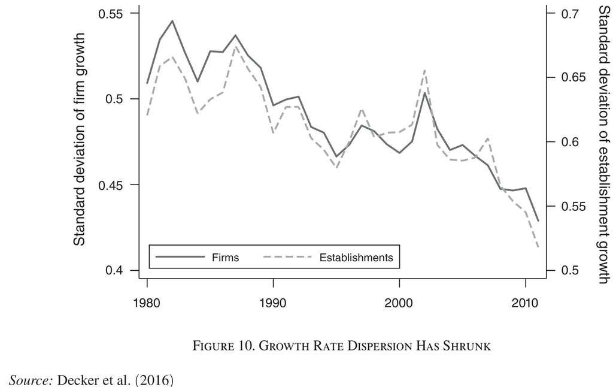

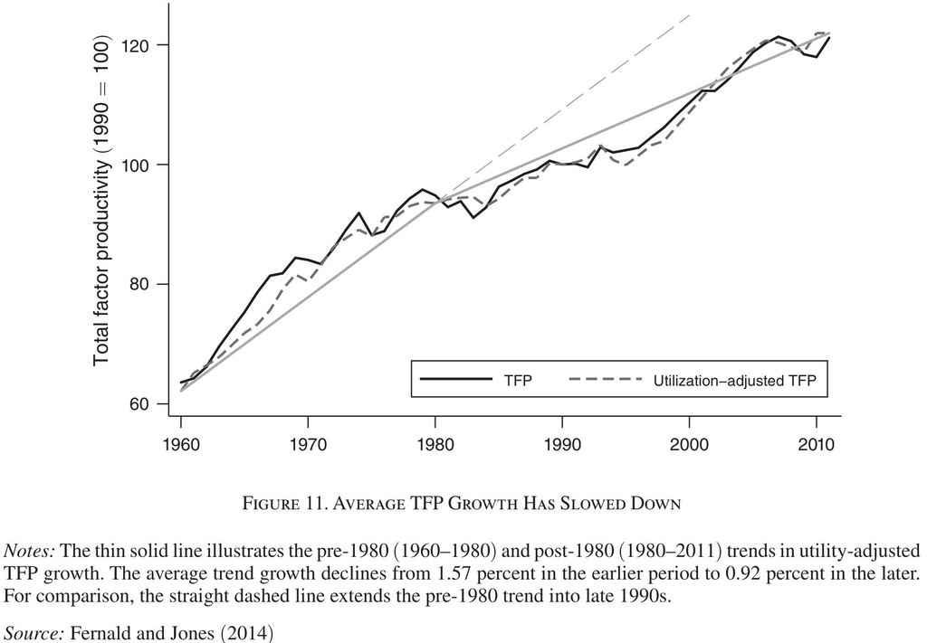

1. Market concentration↑
- (ビッグ・)データ、業務のデジタル化←規模の経済
- ICT利用度 $\stackrel{+}{\sim}$ 市場集中度
6. (Labour) Productivity gap between frontier and laggard firms↑
- 暗黙知tacit knowledgeの重要性
- 知識拡散の低下←労働移動の低下、知的財産保護の強化
2. Average markups↑
- 産業のDX率 $\stackrel{+}{\sim}$ マークアップ
  - DX: Digital transformation, ICTツールを使い職場・作業を効率化すること
7. Firm entry rate↓
   - 出生率の低下
   - 簡単な発明機会の喪失
3. Profit share of GDP↑
   - 理由は労働分配率低下と同じ
8. Share of young firms↓
   - 出生率の低下
4. Labor share of output↓
- superstar企業: 生産性が高くマークアップ率も高いが労働分配率が低い
9. Job reallocation↓
   - 規制
5. Market concentration↑ $\stackrel{+}{\sim}$ L share↓
- superstar企業: 生産性が高くマークアップ率も高いが労働分配率が低い
10. dispersion of firm growth↓
- 知識拡散の低下←労働移動の低下、知的財産保護の強化
- 反トラスト法運用の弱体化: 競争法におけるシカゴ学派台頭↔︎ニュー・ブランダイス学派

#### References

Akcigit, Ufuk, and Sina T. Ates. 2021. “Ten Facts on Declining Business Dynamism and Lessons from Endogenous Growth Theory.” *American Economic Journal: Macroeconomics* 13 (1): 257–98. https://doi.org/10.1257/mac.20180449.

Autor, David H. 2013. “The ‘Task Approach’ to Labor Markets: An Overview.” *Journal for Labour Market Research* 46 (3): 185–99.

[figure not shown]

http://seiroito.github.io/SHLectures/lec_slides/2024/RP/RP11.html